# method_niches_climatiques

# Données

Les données utilisées pour le Québec proviennent de la base de données Atlas de Biodiversité Québec. Ces données incluent notamment les données du CDPNQ pour les vertébrés, les données de BORAQ pour les amphibiens et reptiles et les données eBird, EPOQ et de l’Atlas des oiseaux nicheurs.

Afin de construire les niches climatiques sur la majorité de l’aire de répartition des espèces, les occurrences des différentes espèces en Amérique du Nord (Canada et États-Unis) ont également été utilisées. Pour ce faire, les données GBIF (hors-Québec) et eBird ont été utilisées.

# Variables

### Climat

La principale variable climatique utilisée est la température moyenne annuelle. Plusieurs autres variables climatiques sont disponibles, mais la pertinence de celles-ci sera déterminée lors des rencontres avec les experts.

### Habitat

En général, les conditions climatiques ne sont pas les seuls éléments expliquant la distribution des espèces et pour ajouter du réalisme aux modèles de distribution, il est essentiel de tenir compte des variables autres que les variables climatiques. Pour cette raison, des variables d’habitat ont également été intégrées aux modèles. Toutefois, dans un contexte de changements climatiques et de distributions projetées, plusieurs variables pertinentes ont dues être éliminées. En effet, seules des variables d’habitats qui demeureront stables dans le temps vis-à-vis des changements climatiques ont été considérées. Par exemple, le relief et l’élévation ne changeront pas dans le temps avec les changements climatiques et peuvent donc être utilisés dans les modèles. D’autres variables comme le pourcentage de forêt feuillue n’ont pu être considérées puisque la composition des forêts est susceptible d’être affectée par les changements climatiques.

Dans certains cas, des variables ont été considérées comme demeurant stables dans le temps, bien qu’à long terme, les changements climatiques pourraient avoir un impact sur ces variables. Par exemple, les milieux humides pourraient être influencés par les changements climatiques, mais nous avons considéré que cette influence serait probablement faible sur les périodes de temps considérées pour les analyses. Il en va de même pour les milieux agricoles et urbains. Dans certains cas, le milieu forestier (indépendemment de la composition forestière) a été considéré comme étant stable dans le temps pour les espèces trouvées dans l’extrême sud du Québec. Pour ces espèces, l’extension anticipée de leur aire de répartition ne dépassera généralement pas la limite actuelle des milieux forestiers et on peut donc assumer que le fait de considérer la forêt comme un prédicteur ne provoquera pas une troncation dans les aires de répartition futures.

### Variables disponibles

Les variables disponibles à l’échelle nord-américaine et québécoise sont présentées ci-dessous. Les variables qui seront vraisemblablement affectées par les changements climatiques et qui n’ont pas été utilisées sont marquées d’un trait.

type

collection

variable

Québec

Amérique du Nord

climat

chelsa-clim

annual_precipitation_amount

climat

chelsa-clim

annual_range_of_air_temperature

climat

chelsa-clim

isothermality

climat

chelsa-clim

mean_annual_air_temperature

climat

chelsa-clim

mean_daily_maximum_air_temperature_of_the_warmest_month

climat

chelsa-clim

mean_daily_mean_air_temperatures_of_the_coldest_quarter

climat

chelsa-clim

mean_daily_mean_air_temperatures_of_the_driest_quarter

climat

chelsa-clim

mean_daily_mean_air_temperatures_of_the_warmest_quarter

climat

chelsa-clim

mean_daily_mean_air_temperatures_of_the_wettest_quarter

climat

chelsa-clim

mean_daily_minimum_air_temperature_of_the_coldest_month

climat

chelsa-clim

mean_diurnal_air_temperature_range

climat

chelsa-clim

mean_monthly_precipitation_amount_of_the_coldest_quarter

climat

chelsa-clim

mean_monthly_precipitation_amount_of_the_driest_quarter

climat

chelsa-clim

mean_monthly_precipitation_amount_of_the_warmest_quarter

climat

chelsa-clim

mean_monthly_precipitation_amount_of_the_wettest_quarter

climat

chelsa-clim

precipitation_amount_of_the_driest_month

climat

chelsa-clim

precipitation_amount_of_the_wettest_month

climat

chelsa-clim

precipitation_seasonality

climat

chelsa-clim

temperature_seasonality

habitat

cec_land_cover_percentage

barren

habitat

cec_land_cover_percentage

coniferous

habitat

cec_land_cover_percentage

cropland

habitat

cec_land_cover_percentage

deciduous

habitat

cec_land_cover_percentage

lichen

habitat

cec_land_cover_percentage

mixed

habitat

cec_land_cover_percentage

polar_grass

habitat

cec_land_cover_percentage

polar_lichen

habitat

cec_land_cover_percentage

polar_shrub

habitat

cec_land_cover_percentage

snow

habitat

cec_land_cover_percentage

taiga

habitat

cec_land_cover_percentage

temperate_deciduous

habitat

cec_land_cover_percentage

temperate_grass

habitat

cec_land_cover_percentage

temperate_shrub

habitat

cec_land_cover_percentage

tropical_deciduous

habitat

cec_land_cover_percentage

tropical_evergreen

habitat

cec_land_cover_percentage

tropical_grass

habitat

cec_land_cover_percentage

tropical_shrub

habitat

cec_land_cover_percentage

urban

habitat

cec_land_cover_percentage

water

habitat

cec_land_cover_percentage

wetland

habitat

distance_to_roads

distance_to_roads

habitat

earthenv_topography

elevation

habitat

earthenv_topography

ruggedness

habitat

earthenv_topography_derived

geomflat

habitat

earthenv_topography_derived

geomfootslope

habitat

ghmts

human_modification

habitat

mhc

mhc

habitat

mhp2023_percentage

eau_peu_profonde

habitat

mhp2023_percentage

indifferencie

habitat

mhp2023_percentage

marais

habitat

mhp2023_percentage

marecage

habitat

mhp2023_percentage

prairie_humide

habitat

mhp2023_percentage

tourbiere_boisee

habitat

mhp2023_percentage

tourbiere_indifferenciee

habitat

mhp2023_percentage

tourbiere_minerotrophe

habitat

mhp2023_percentage

tourbiere_ombrotrophe

habitat

sigeom_zones_morphosedimentologiques_percentage

alluvion

habitat

sigeom_zones_morphosedimentologiques_percentage

anthropogenique

habitat

sigeom_zones_morphosedimentologiques_percentage

depot

habitat

sigeom_zones_morphosedimentologiques_percentage

eolien

habitat

sigeom_zones_morphosedimentologiques_percentage

glaciaire

habitat

sigeom_zones_morphosedimentologiques_percentage

glaciolacustre

habitat

sigeom_zones_morphosedimentologiques_percentage

glaciomarin

habitat

sigeom_zones_morphosedimentologiques_percentage

lacustre

habitat

sigeom_zones_morphosedimentologiques_percentage

marin

habitat

sigeom_zones_morphosedimentologiques_percentage

organique

habitat

sigeom_zones_morphosedimentologiques_percentage

quaternaire

habitat

sigeom_zones_morphosedimentologiques_percentage

roche

habitat

sigeom_zones_morphosedimentologiques_percentage

till

habitat

silvis

lai

habitat

silvis

ndvi

habitat

soilgrids

bulk_density

habitat

soilgrids

clay

habitat

soilgrids

nitrogen

habitat

soilgrids

organic_carbon_density

habitat

soilgrids

ph

habitat

soilgrids

sand

habitat

soilgrids

silt

habitat

soilgrids

soil_organic_carbon

habitat

twi

twi

# Modélisation

Afin de comparer différentes approches de modélisation, plusieurs modèles ont été effectués, notamment des modèles basés uniquement sur le climat, des modèles basés uniquement sur des variables d’habitat, des modèles combinant à la fois les variables de climat et d’habitat au sein d’un même modèle ou des modèles combinés selon une approche hiérarchique couplant un modèle de climat à un modèle d’habitat.

Pour les modèles incluant des variables d’habitat, nous avons également utilisé deux échelles de modélisation, soit un modèle effectué à l’échelle de l’Amérique du Nord et un modèle effectué au niveau du Québec.

### Modèles de climat

Tous les modèles avec une composante climat ont été effectuées à l’échelle nord-américaine afin de couvrir la majorité de l’aire de distribution des espèces et ainsi éviter le problème de troncation de la niche [Guisan *et al*. 2025](https://doi.org/10.1111/1365-2745.70063). En effet, le Québec représente une petite partie de l’aire de distribution de la majorité des espèces modélisées et il serait hasardeux d’établir les relations entre le climat et la présence des espèces sur une portion réduite des valeurs climatiques auxquelles ces espèces sont soumises sur le territoire québécois.

Deux modèles climatiques ont été effectués. Le premier est un modèle basé sur l’algorithme Maxent. Pour ce modèle, seuls des effets quadratiques de la température moyenne annuelle ont été utilisés. Afin de donner plus de flexibilité à la relation entre le climat et la présence de l’espèce, des modèles additifs à formes contraintes ont été utilisés. Plus spécifiquement, des formes strictement concaves sont permises par une base “cv”.

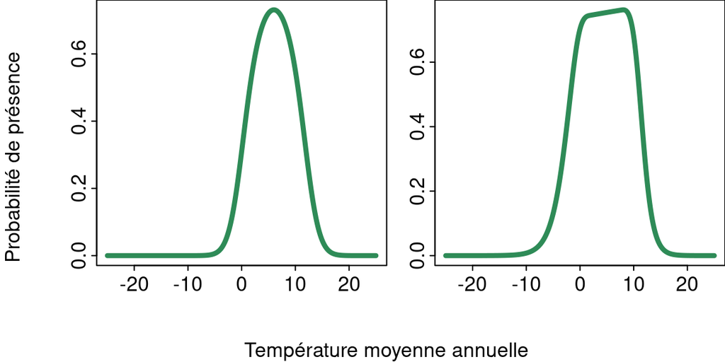

### Modèles d’habitat

Deux modèles on été effectués, un modèle à l’échelle nord américaine et un modèle à l’échelle du Québec. Ces modèles ne sont pas d’intérêt en soir, mais ils sont plutôt destinés à être couplés avec les modèles climatiques. Le modèle à l’écehelle du Québec comporte 2 avantages:

- il permet de prendre en compte certaines variables d’habitat qui ne sont disponibles qu’en territoire québécois
- il permet d’obtenir un modèle d’habitat basé uniquement sur la réalité locale propre au Québec

### Modèles de climat et habitat

Ce modèle est composé uniquement des données à l’échelle de l’Amérique du Nord. Il comporte à la fois les variables climatiques et d’habitat au sein d’un même modèle. Il s’agit de l’approche standard qui est généralement utilisée pour modéliser la distribution des espèces.

### Modèles combinés

L’idée derrière les modèles combinés est qu’à grande échelle, les espèces ont toutes une région où les conditions climatiques sont favorables à leur présence et à plus fine échelle, les variables de couverture du sol ont un plus grand impact et seuls les habitats favorables à la présence de l’espèce peuvent être occupés. Les avantages d’un telle approche sont:

- permet de coupler des modèles effectués à différentes échelles (*e.g.* un modèle climatique à grande échelle couplé à un modèle d’habitat à plus petit échelle)
- permet d’isoler l’effet des variables climatiques de celui des variables d’habitats dans un contexte où les deux types de variables sont potentiellement spatialement corrélées et attribuer les variations en probabilité de présence ou d’abondance à grande échelle aux variables climatiques

## Paramétrisation des modèles

Afin d’atténuer les problèmes de prédictions hors des aires de distribution connues, des pseudo-absences ont également été ajoutées à l’extérieur d’une zone tampon de 250km autour des observations de l’espèce ciblée. Considérant que la plupart des espèces modélisées sont relativement bien connues, cette approche présume qu’il est peu probable de trouver de nouvelles populations à une distance de plus de 250km des occurrences connues. Cette valeur de 250km pourra être réajustée au besoin en fonction des espèces et des commentaires des experts.

## Variables par espèces

| species | variables |
| --- | --- |
| Pseudacris triseriata | wetland, marais, marecage, geomflat |
| Hemidactylium scutatum | tourbiere, marais, organique |
| Gyrinophilus porphyriticus | elevation, ruggedness, forest, geomflat, twi |
| Desmognathus ochrophaeus | elevation, ruggedness, forest, geomflat, twi |
| Emydoidea blandingii | wetland, marais, marecage, geomflat, water, eau_peu_profonde |
| Glyptemys insculpta | wetland, marais, marecage, geomflat, water, eau_peu_profonde, sand |
| Nerodia sipedon | wetland, marais, marecage, geomflat, water, eau_peu_profonde |
| Lampropeltis triangulum | wetland, marais, marecage, geomflat, water, eau_peu_profonde |
| Aquila chrysaetos | elevation, ruggedness |
| Catharus bicknelli | elevation, ruggedness |
| Setophaga cerulea | forest, ph, silt, nitrogen |
| Coturnicops noveboracensis | flat, marais, wetland, prairie_humide |
| Ixobrychus exilis | geomflat, wetland, marais, eau_peu_profonde |
| Glaucomys volans | forest |

## Périodes de nidification pour les oiseaux

Pour les oiseaux, les modèles ont été restreints aux périodes de nidification des espèces ciblées. Des modèles pourraient également être réalisés pour les espèces susceptibles d’hiverner sous nos latitudes avec les changements climatiques. Les périodes de nidification telles que définies par le jeu de données *eBird Status and Trends* ([Fink *et al*. 2024](https://doi.org/10.2173/WZTW8903)) ont été utilisées. Ces périodes pourraient être modifiées pour mieux réfléter les périodes de nidifications au Québec.

| Espèces | Début | Fin |
| --- | --- | --- |
| Aquila chrysaetos | 06-07 | 08-23 |
| Catharus bicknelli | 06-07 | 07-12 |
| Setophaga cerulea | 05-24 | 07-12 |
| Coturnicops noveboracensis | 06-07 | 08-24 |
| Ixobrychus exilis | 06-07 | 07-19 |

# Effet des variables

Pour chaque modèle, les effets marginaux des différentes variables considérées ont été calculés en fixant les autres variables à leur valeurs moyennes. Afin de visualiser les données par rapport à l’effet des variables, deux histogrammes de densité ont été ajoutés aux graphiques. Un premier a été employé pour illustrer la distribution de l’ensemble des points utilisés (observations et pseudo-absences) par rapport aux variations de la variable ciblée et un second pour visualiser l’abondance relative de l’espèce par rapport à la variable ciblée et à l’ensemble des points utilisés.

# Scénarios climatiques